# draft_peak_qc.R

llorenzi

2021-08-25

```r
##
##
## Purpose of script: analyse consensus and per sample peaks
##
## Author: Lucia Lorenzi
##
## Date Created: 2021-08-12
##
## Email: lucialorenzi90@gmail.com
##
```

```r
##
## Notes:
##
##
```

```r
options(scipen = 999)
```

```r
## load up the packages we will need:  (uncomment as required)

require(tidyverse)
require(data.table)
require(ChIPseeker)
```

Consensus peaks were generated as follows:  
-First MACS2 narrow peaks were generated for each sample removing duplicates *(macs2 callpeak -t $1.primary_chr.quality.concordant.sorted.markedDups.bam -n $1.primary_chr.quality.concordant.sorted.markedDups.nodups -f BAMPE -g hs –nomodel –nolambda –keep-dup 1 –call-summits –verbose 3)*  
-Then columns 1-4, 9 and 6 from all files were concatenated in a single file *(cut -f1-4,6,9 $s >> /scratch/llorenzi/MDS/ATAC-seq/merged_peaks/all_peaks.primary_chr.quality.concordant.sorted.markedDups.nodups_peaks.narrowPeak done < narrowPeak_files_paths.txt)*  
and sorted by coordinates *(sort -k1,1 -k2,2n all_peaks.primary_chr.quality.concordant.sorted.markedDups.nodups_peaks.narrowPeak > all_peaks.primary_chr.quality.concordant.sorted.markedDups.nodups_peaks.sorted.narrowPeak)*  
-Finally, bedtools merge was used to merge overlapping peaks, count the number of samples that contributed to each merged peak,  
get the list of samples that contributed to each merged peak and report the mean of merged peaks q-values: *(sed “s/.primary_chr.quality.concordant.sorted.markedDups.nodups_peak_[0-9a-z]*//” all_peaks.primary_chr.quality.concordant.sorted.markedDups.nodups_peaks.sorted.narrowPeak | bedtools merge -c 4,4,6 -o count_distinct,distinct,mean -i - > merged_peaks.primary_chr.quality.concordant.sorted.markedDups.nodups_peaks.sorted.bed)*

```r
conspeaks=fread("~/MDS/ATAC-seq/data/macs2_peaks/merged_peaks.primary_chr.quality.concordant.sorted.markedDups.nodups_peaks.sorted.bed")
sample_info <- read.csv("/Users/llorenzi/MDS/ATAC-seq/analyses/QC/sample_stats/summary_QC_after_alignment.csv")
DT::datatable(sample_info)
```

|  | sample_id | patient | LPS | total_sequenced_read_pairs | read_pairs_after_trimming | overall_alignment_percent | properly_aligned_pairs | pairs_aligned_exactly_once | pairs_aligned_more_than_once | single_aligned_mates | percent_properly_aligned_pairs | number_of_MT_reads | percent_MT_raw_reads | MT_proper_pairs | percent_MT_proper_pairs | primarychr_proper_pairs | percent_primarychr_proper_pairs | primarychr_MAPQ20_proper_pairs | percent_primarychr_MAPQ20_proper_pairs | percent_proper_pairs_pass_MAPQ | percent_duplicates | mean_insert_size | insert_size_sd |
| --- | --- | --- | --- | --- | --- | --- | --- | --- | --- | --- | --- | --- | --- | --- | --- | --- | --- | --- | --- | --- | --- | --- | --- |
| 1 | AT-MDS1.1 | MDS1 | 1 | 14717599 | 14609987 | 98.67 | 14232621 | 10152483 | 4080138 | 244501 | 97.42 | 5767553 | 19.74 | 2829785 | 19.88 | 11315005 | 79.5 | 10268689 | 72.15 | 90.75 | 4.8 | 184.7 | 96.8 |
| 2 | AT-MDS1.2 | MDS1 | 2 | 16687257 | 16557957 | 98.84 | 16121534 | 11280481 | 4841053 | 318940 | 97.36 | 7515324 | 22.69 | 3682593 | 22.84 | 12348943 | 76.6 | 11206435 | 69.51 | 90.75 | 3.38 | 183.9 | 95.3 |
| 3 | AT-MDS16.1 | MDS16 | 1 | 18743149 | 18636464 | 98.69 | 18197454 | 13794190 | 4403264 | 274493 | 97.64 | 3014296 | 8.09 | 1477434 | 8.12 | 16518966 | 90.78 | 14840612 | 81.55 | 89.84 | 8.02 | 184.8 | 95.4 |
| 4 | AT-MDS16.2 | MDS16 | 2 | 20754679 | 20636814 | 98.75 | 20156738 | 15532195 | 4624543 | 307534 | 97.67 | 2324092 | 5.63 | 1137229 | 5.64 | 18791115 | 93.22 | 16924244 | 83.96 | 90.07 | 2.88 | 183.1 | 96.2 |
| 5 | AT-MDS17.1 | MDS17 | 1 | 42257580 | 41860284 | 98.84 | 40893543 | 26829888 | 14063655 | 722805 | 97.69 | 21065273 | 25.16 | 10324722 | 25.25 | 30192353 | 73.83 | 26794993 | 65.52 | 88.75 | 6.62 | 193.5 | 91.4 |
| 6 | AT-MDS17.2 | MDS17 | 2 | 35567644 | 35242381 | 98.84 | 34375403 | 21740128 | 12635275 | 669602 | 97.54 | 19528399 | 27.71 | 9563707 | 27.82 | 24483880 | 71.22 | 21549400 | 62.69 | 88.01 | 5.25 | 186 | 92.5 |
| 7 | AT-MDS20.1 | MDS20 | 1 | 39536070 | 39214785 | 98.82 | 38303976 | 29081171 | 9222805 | 599360 | 97.68 | 5157131 | 6.58 | 2522267 | 6.58 | 35301618 | 92.16 | 31661254 | 82.66 | 89.69 | 4.58 | 170.3 | 87.1 |
| 8 | AT-MDS20.2 | MDS20 | 2 | 26203625 | 26003637 | 98.82 | 25400437 | 19438709 | 5961728 | 398530 | 97.68 | 3167483 | 6.09 | 1547025 | 6.09 | 23532312 | 92.65 | 21125492 | 83.17 | 89.77 | 3.82 | 179 | 91.4 |
| 9 | AT-MDS21.1 | MDS21 | 1 | 26119586 | 25887155 | 99.11 | 25404429 | 18457149 | 6947280 | 355486 | 98.14 | 8067379 | 15.58 | 3956675 | 15.57 | 21223110 | 83.54 | 19160998 | 75.42 | 90.28 | 3.17 | 195.4 | 91.2 |
| 10 | AT-MDS21.2 | MDS21 | 2 | 27471803 | 27224084 | 99 | 26668462 | 20322707 | 6345755 | 394037 | 97.96 | 5220339 | 9.59 | 2552458 | 9.57 | 23851906 | 89.44 | 21590502 | 80.96 | 90.52 | 3.41 | 201.3 | 101.7 |

[output cut: 14 more lines]

```r
libsizes <- sort(sample_info$primarychr_MAPQ20_proper_pairs)
names(libsizes) <- sample_info$sample_id[order(sample_info$primarychr_MAPQ20_proper_pairs)]
n_total_samps=length(libsizes)

#for each peak generate list of samples in which it is found:
samples_lists <- sapply(conspeaks$V5, function(x) strsplit(x,","))

#some statistics:
#Consensus peak length:
peak_len <- conspeaks$V3 - conspeaks$V2

summary(peak_len)
```

```
##    Min. 1st Qu.  Median    Mean 3rd Qu.    Max.
##   170.0   247.0   343.0   468.2   539.0 18144.0
```

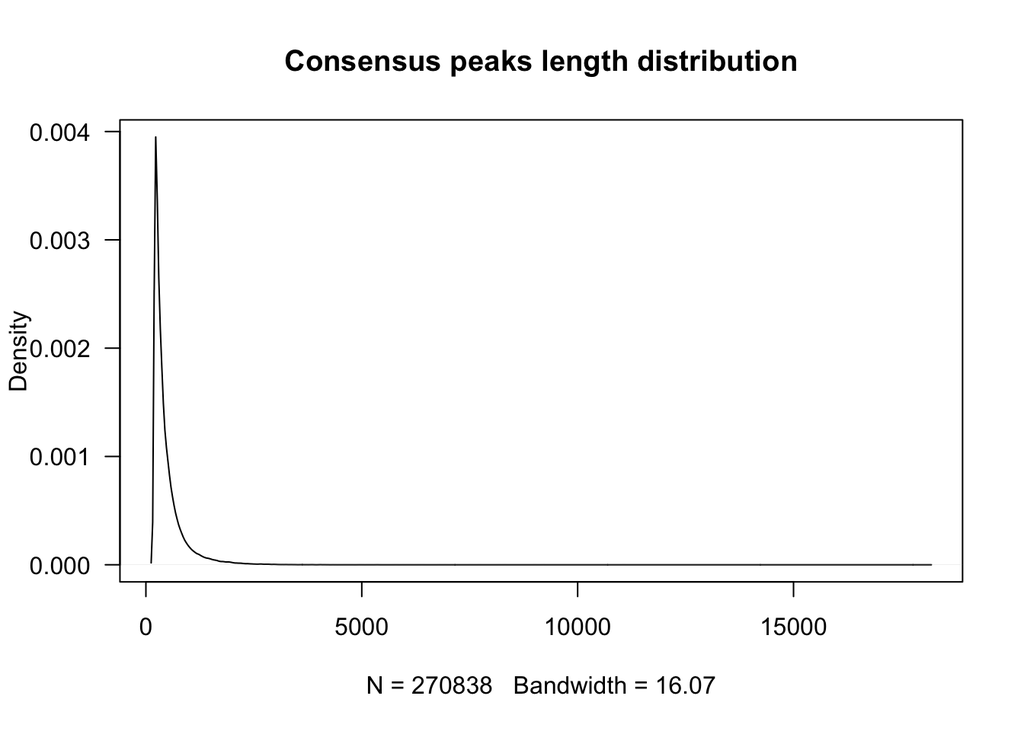

```r
par(las=1)
plot(density(peak_len), main="Consensus peaks length distribution")
```

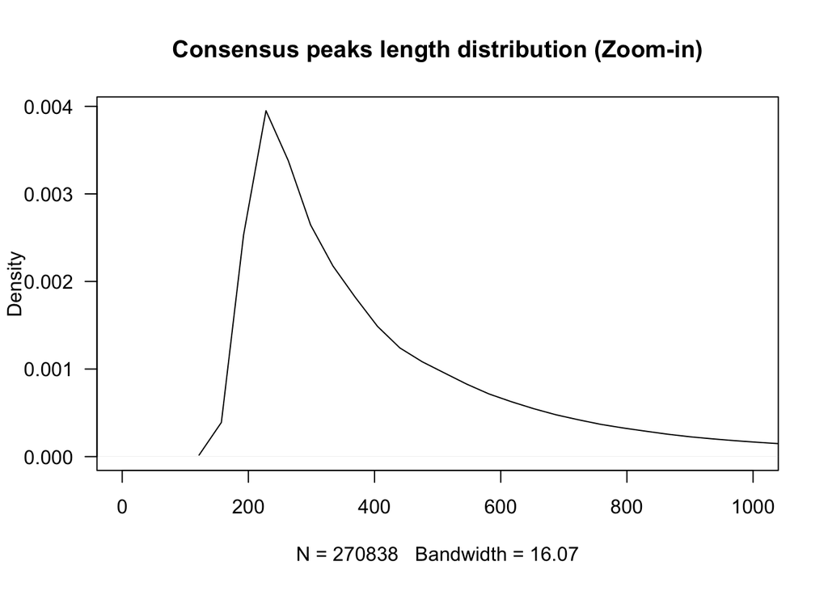

```r
plot(density(peak_len), main="Consensus peaks length distribution (Zoom-in)",xlim=c(0,1000))
```

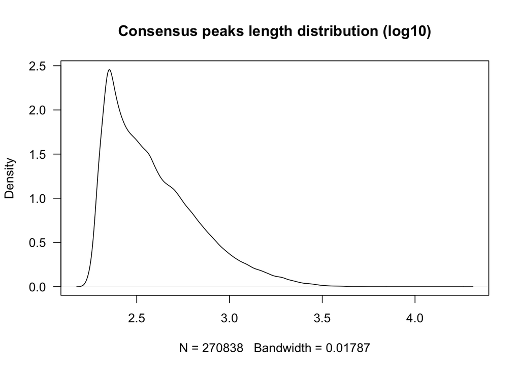

```r
plot(density(log10(peak_len)),main="Consensus peaks length distribution (log10)")
```

```r
#Total number of peaks
n_total_peaks=nrow(conspeaks)
n_total_peaks
```

```
## [1] 270838
```

```r
#Number of peaks found in all samples:
sum(conspeaks$V4==n_total_samps)
```

```
## [1] 2568
```

```r
#What percentage of consensus peaks are seen in all samples?
#% of peaks common to all samples:
table(conspeaks$V4)/n_total_peaks*100
```

```
##
##          1          2          3          4          5          6          7
## 60.3504678 11.9754244  5.1647110  3.2432672  2.3094987  1.8147380  1.4927743
##          8          9         10         11         12         13         14
##  1.3214542  1.1660107  1.0652124  0.9448453  0.8318626  0.7487871  0.6852805
##         15         16         17         18         19         20         21
##  0.6180817  0.5752516  0.5626980  0.6169740  0.6838036  0.7284798  0.7281105
##         22         23         24
##  0.7336489  0.6904496  0.9481683
```

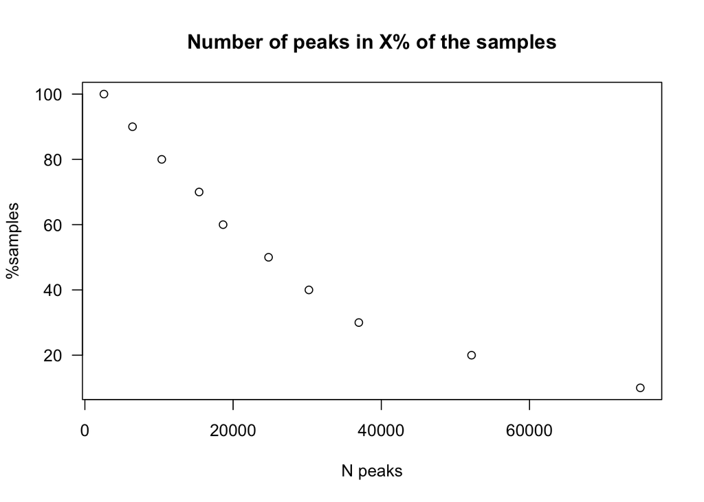

```r
#less than 1% of the peaks are found in all samples
#and 60% of the peaks are found in only one sample!

#how many peaks are in X% of the samples?
n_peaks_in_Xpercent_samps=c()

frac_samples <- seq(0.1,1,by=0.1)
for(perc in frac_samples){
  n_peaks_in_Xpercent_samps=c(n_peaks_in_Xpercent_samps,sum(conspeaks$V4>=perc*n_total_samps))

}
plot(n_peaks_in_Xpercent_samps, frac_samples*100,main="Number of peaks in X% of the samples",
     ylab="%samples",xlab="N peaks")
```

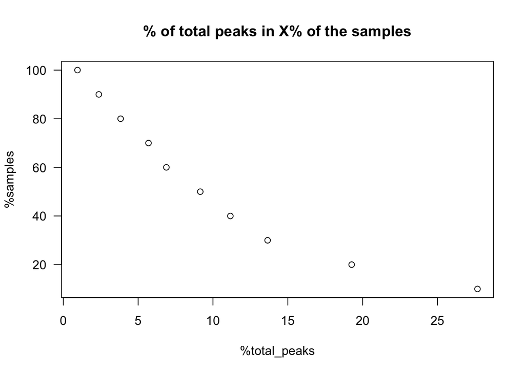

```r
plot(n_peaks_in_Xpercent_samps/n_total_peaks*100,frac_samples*100,
     main="% of total peaks in X% of the samples",
     ylab="%samples",xlab="%total_peaks")
```

```r
#add peak annotation
library(TxDb.Hsapiens.UCSC.hg38.knownGene)
peakfile <- "~/MDS/ATAC-seq/data/macs2_peaks/merged_peaks.primary_chr.quality.concordant.sorted.markedDups.nodups_peaks.sorted.bed"

txdb <- TxDb.Hsapiens.UCSC.hg38.knownGene
peakAnno <- annotatePeak(peakfile, tssRegion=c(-3000, 3000), TxDb=txdb)
```

```
## >> loading peak file...               2021-08-25 12:51:30
## >> preparing features information...      2021-08-25 12:51:31
## >> identifying nearest features...        2021-08-25 12:51:34
## >> calculating distance from peak to TSS...   2021-08-25 12:51:41
## >> assigning genomic annotation...        2021-08-25 12:51:41
## >> assigning chromosome lengths           2021-08-25 12:52:28
## >> done...                    2021-08-25 12:52:28
```

```r
#View(as.data.frame(peakAnno))
#knitr::kable(as.data.frame(peakAnno))
#add some more info: translate geneID, add p-values
gene_translation_file <- "/Users/llorenzi/references/human/biomart_tables/Human_Ensembl_genes_104_GRCh38.p13_to_NCBI.tsv"
library(data.table)
gene_translation <- fread(gene_translation_file)
peakAnnodf <- as.data.frame(peakAnno)
table(peakAnnodf$geneId%in%gene_translation$`NCBI gene (formerly Entrezgene) ID`)
```

```
##
##  FALSE   TRUE
##  19360 251478
```

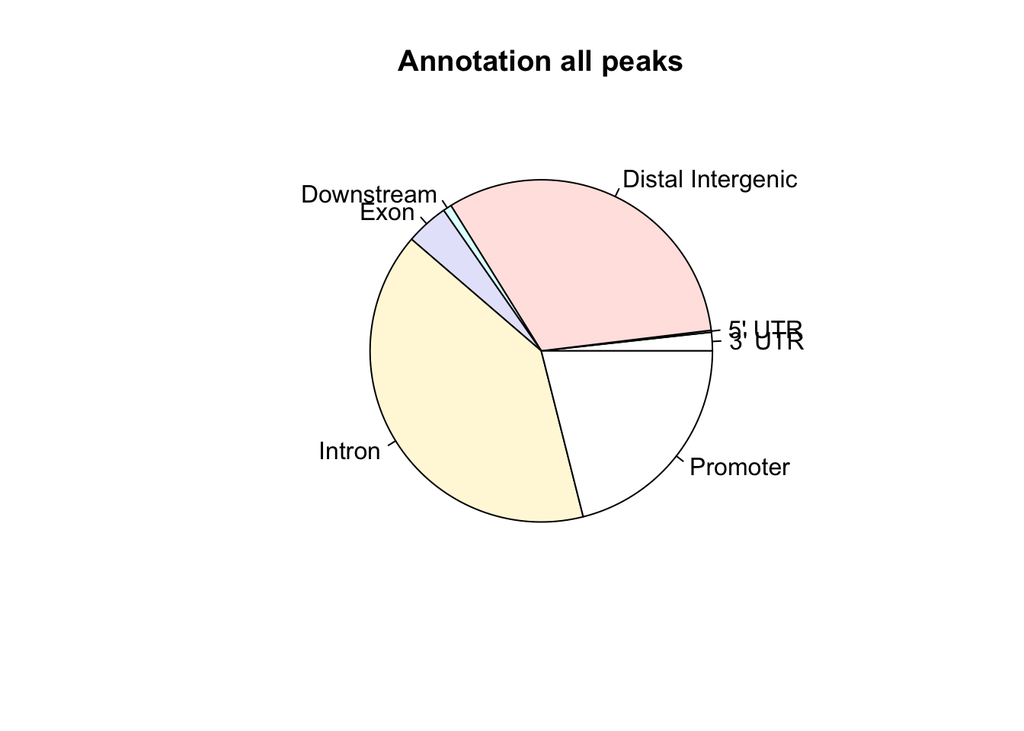

```r
peakAnnodf$gene_name <- gene_translation$`Gene name`[match(peakAnnodf$geneId,
                                                           gene_translation$`NCBI gene (formerly Entrezgene) ID`)]

peakAnnodf$simplified_annot <- gsub("(\\.*)( \\(.*)","\\1",peakAnnodf$annotation)


pie(table(peakAnnodf$simplified_annot), main="Annotation all peaks")
```

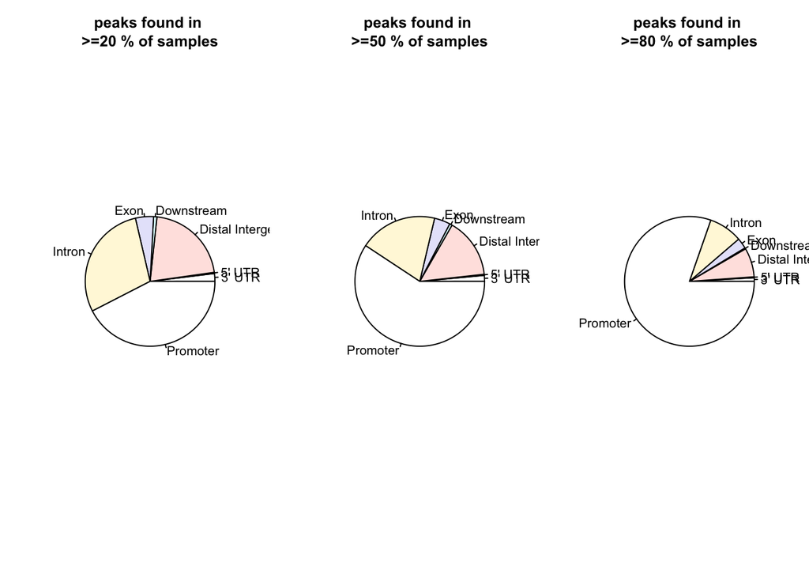

```r
#
par(mfrow=c(1,3))
for (fr in frac_samples[c(2,5,8)]) {
 pie(table(peakAnnodf$simplified_annot[peakAnnodf$V4>=fr*n_total_samps]),
     main=paste0("peaks found in \n>=",fr*100," % of samples"))

}
```

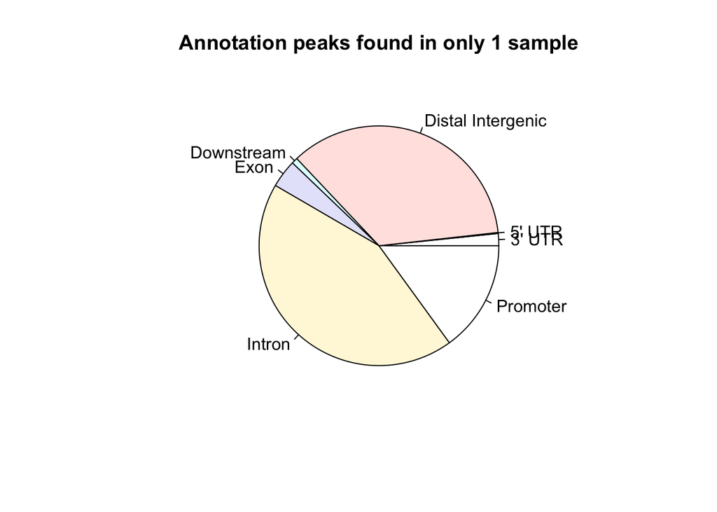

```r
#Annotation unique peaks
par(mfrow=c(1,1))
pie(table(peakAnnodf$simplified_annot[peakAnnodf$V4==1]), main="Annotation peaks found in only 1 sample")
```

```r
#per sample annotations:

# pdf("~/MDS/ATAC-seq/analyses/peak_annotation/peak_annot_per_sample1.pdf")
# par(mfrow=c(3,4))
# for (samp in sort(names(libsizes))[1:12]) {
#   cond=sapply(samples_lists, function(x)samp%in%x)
#   pie(table(peakAnnodf$simplified_annot[cond]), main=samp)
# }
# dev.off()

# pdf("~/MDS/ATAC-seq/analyses/peak_annotation/peak_annot_per_sample2.pdf")
# par(mfrow=c(3,4))
# for (samp in sort(names(libsizes))[13:24]) {
#   cond=sapply(samples_lists, function(x)samp%in%x)
#   pie(table(peakAnnodf$simplified_annot[cond]), main=samp)
# }
# dev.off()

#number of peaks vs libsize
names(libsizes)
```

```
##  [1] "AT-MDS35.2" "AT-MDS1.1"  "AT-MDS1.2"  "AT-MDS35.1" "AT-MDS33.2"
##  [6] "AT-MDS31.2" "AT-MDS16.1" "AT-MDS33.1" "AT-MDS16.2" "AT-MDS31.1"
## [11] "AT-MDS21.1" "AT-MDS20.2" "AT-MDS17.2" "AT-MDS21.2" "AT-MDS4.2"
## [16] "AT-MDS17.1" "AT-MDS24.1" "AT-MDS29.2" "AT-MDS4.1"  "AT-MDS29.1"
## [21] "AT-MDS20.1" "AT-MDS26.2" "AT-MDS24.2" "AT-MDS26.1"
```

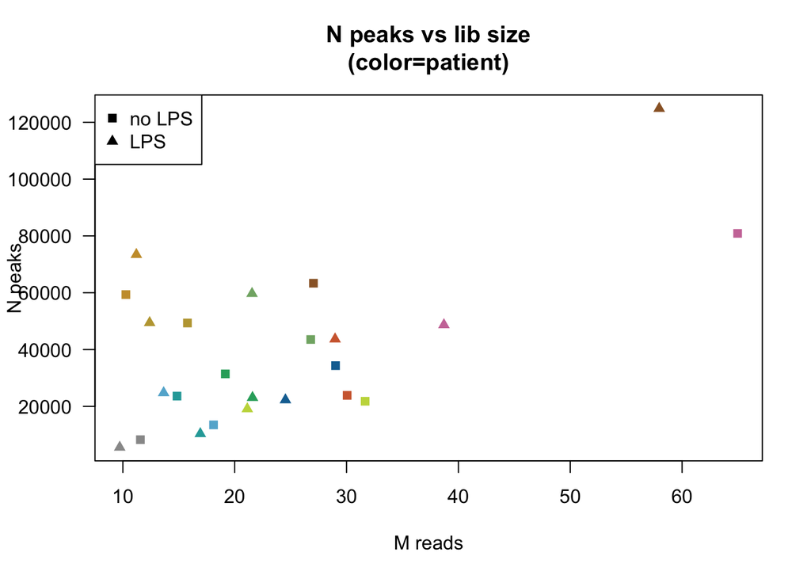

```r
total_peaks_per_sample <- c()

for(samp in names(libsizes)){
  total_peaks_per_sample=c(total_peaks_per_sample,sum(sapply(samples_lists,function(x)samp%in%x)))

}

#plot(libsizes/1000000,total_peaks_per_sample)
library(RColorBrewer)
cbPalette <- c("#999999", "#E69F00", "#56B4E9", "#009E73", "#F0E442", "#0072B2", "#D55E00", "#CC79A7")

cols_12 <- colorRampPalette(cbPalette)(12)
names(cols_12) <- unique(gsub("\\.[0-9]*","",names(libsizes)))
cols_24 <- cols_12[match(gsub("\\.[0-9]*","",names(libsizes)),
                         names(cols_12))]

LPS <- gsub("(.*)(\\.)([0-9]*)","\\3",names(libsizes))
LPS_point_type <- c("1"=15,"2"=17)

par(mfrow=c(1,1))
plot(libsizes/1000000,total_peaks_per_sample,col=cols_24,pch=LPS_point_type[match(LPS,names(LPS_point_type))],main="N peaks vs lib size\n(color=patient)",
     xlab="M reads",ylab="N peaks")
legend("topleft",legend = c("no LPS","LPS"),pch = c(15,17))
```

```r
cor(libsizes/1000000,total_peaks_per_sample)
```

```
## [1] 0.5977044
```

```r
cor(libsizes/1000000,total_peaks_per_sample,method = "spearman")
```

```
## [1] 0.2904348
```

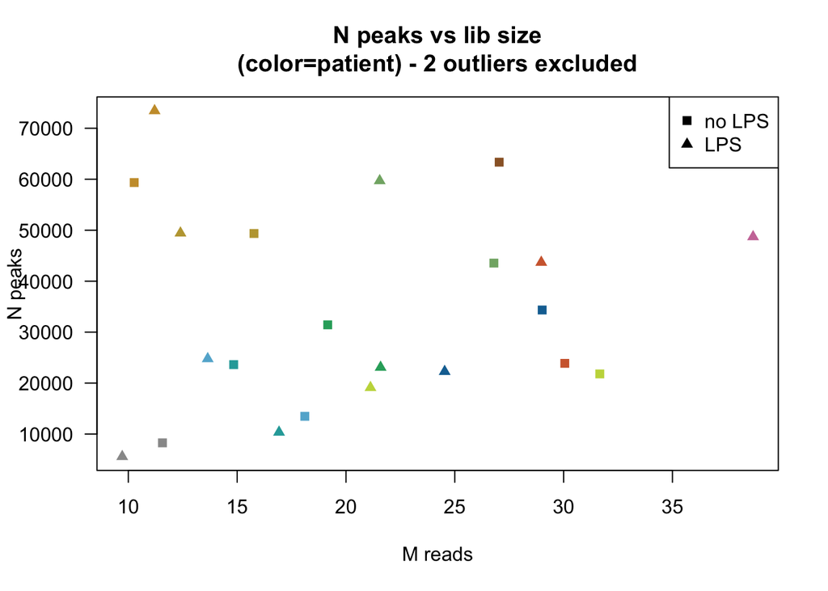

```r
plot(libsizes[1:22]/1000000,total_peaks_per_sample[1:22],col=cols_24,
     pch=LPS_point_type[match(LPS,names(LPS_point_type))][1:22],main="N peaks vs lib size\n(color=patient) - 2 outliers excluded",
     xlab="M reads",ylab="N peaks")
legend("topright",legend = c("no LPS","LPS"),pch = c(15,17))
```

```r
cor(libsizes[1:22]/1000000,total_peaks_per_sample[1:22])
```

```
## [1] 0.09126315
```

```r
cor(libsizes[1:22]/1000000,total_peaks_per_sample[1:22],method = "spearman")
```

```
## [1] 0.07961604
```

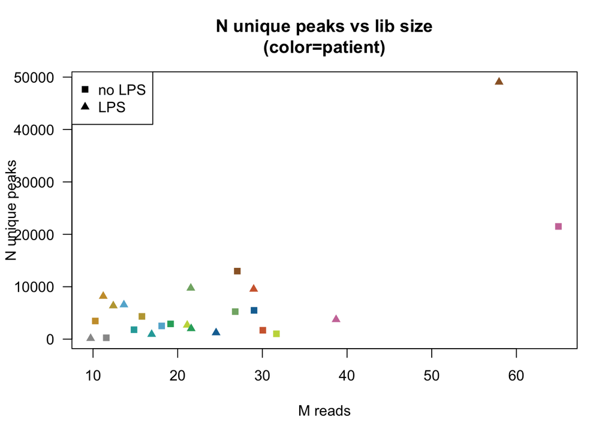

```r
#number unique peaks vs libsize
total_unique_peaks_per_sample <- c()

for(samp in names(libsizes)){
  total_unique_peaks_per_sample=c(total_unique_peaks_per_sample,
                                  sum(conspeaks$V4==1&conspeaks$V5==samp))
}
#
plot(libsizes/1000000,total_unique_peaks_per_sample,col=cols_24,
     pch=LPS_point_type[match(LPS,names(LPS_point_type))],
     main="N unique peaks vs lib size\n(color=patient)",
     xlab="M reads",ylab="N unique peaks")
legend("topleft",legend = c("no LPS","LPS"),pch = c(15,17))
```

```r
cor(libsizes/1000000,total_unique_peaks_per_sample)
```

```
## [1] 0.7091901
```

```r
cor(libsizes/1000000,total_unique_peaks_per_sample,method = "spearman")
```

```
## [1] 0.333913
```

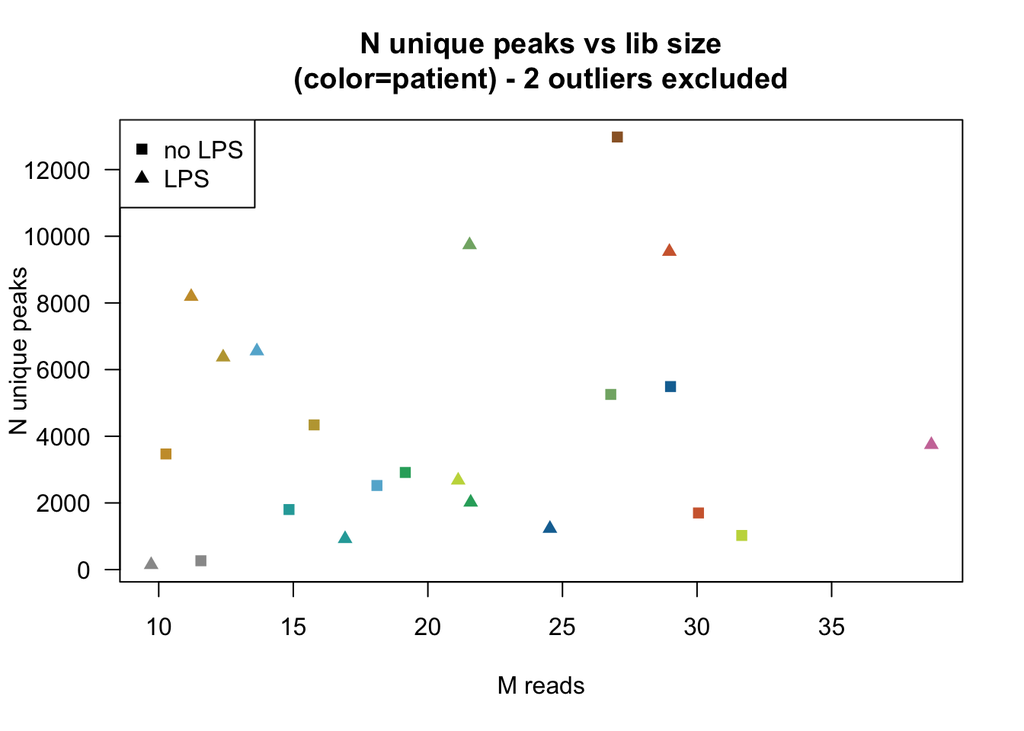

```r
plot(libsizes[1:22]/1000000,total_unique_peaks_per_sample[1:22],col=cols_24[1:22],
     pch=LPS_point_type[match(LPS,names(LPS_point_type))][1:22],
     main="N unique peaks vs lib size\n(color=patient) - 2 outliers excluded",
     xlab="M reads",ylab="N unique peaks")
legend("topleft",legend = c("no LPS","LPS"),pch = c(15,17))
```

```r
cor(libsizes[1:22]/1000000,total_unique_peaks_per_sample[1:22])
```

```
## [1] 0.151916
```

```r
cor(libsizes[1:22]/1000000,total_unique_peaks_per_sample[1:22],method = "spearman")
```

```
## [1] 0.1360813
```

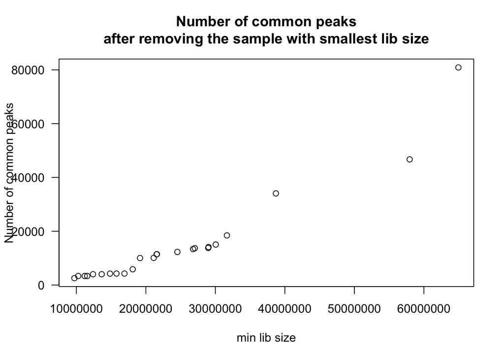

```r
#ideas:
# plot de numero de picos en todas las muestras vs quitar secuencialmente la muestra
# que tiene menos total counts (para ver si el hecho de que haya pocos picos comunes
# a todas las muestras esta relacionado con la gran diferencia en libsize)

#The idea is: if most regions of open chromatin are expected to be seen in all samples,
#then probably the samples with low total reads miss some peaks because of low counts

samps_to_remove=c()
total_common_peaks <- c()
n_total_samps=length(libsizes)
for(samp in names(libsizes)){
  samps_to_remove <- c(samps_to_remove,samp)
  samps_to_keep <- names(libsizes)[!names(libsizes)%in%samps_to_remove]
  cond <- sapply(samples_lists,function(x)all(samps_to_keep%in%x))
  total_common_peaks <- c(total_common_peaks,sum(cond))

}



total_common_peaks <- c(sum(conspeaks$V4==n_total_samps),total_common_peaks[-length(total_common_peaks)])

#plot Number of common peaks vs lib size of the sample with lowest number of peaks
par(las=1)
plot(libsizes,total_common_peaks, xlab="min lib size",ylab="Number of common peaks",
     main="Number of common peaks\nafter removing the sample with smallest lib size")
```

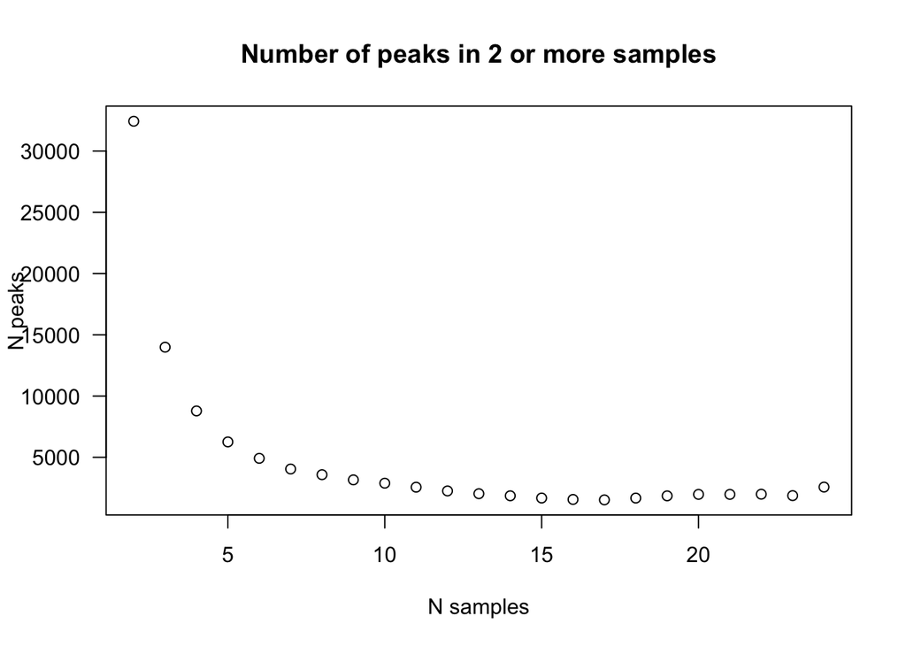

```r
plot(seq_along(libsizes)[-1],as.numeric(table(conspeaks$V4))[-1],
     main="Number of peaks in 2 or more samples",xlab="N samples",ylab="N peaks")
```

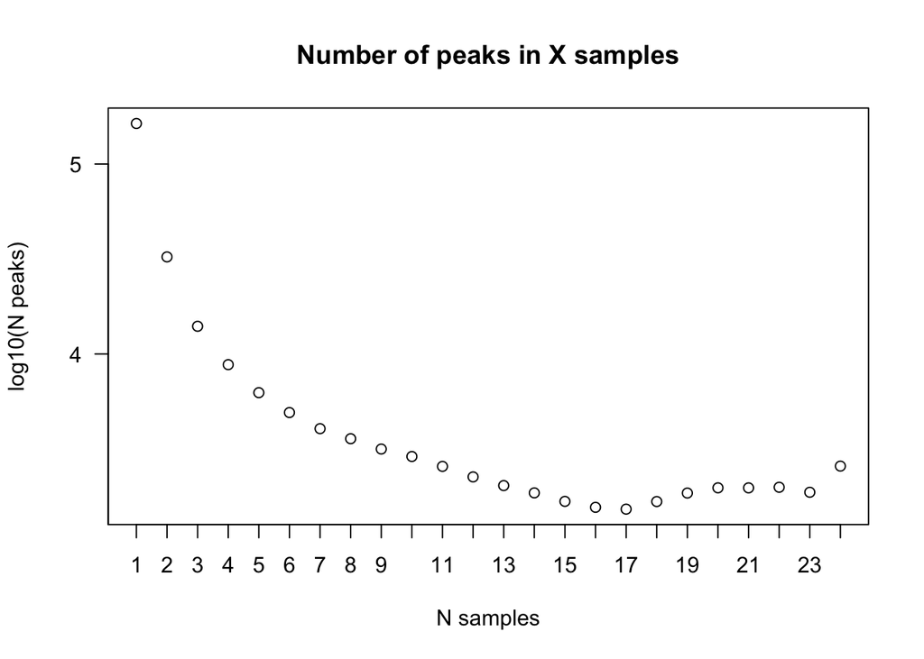

```r
plot(seq_along(libsizes),log10(as.numeric(table(conspeaks$V4))),
     main="Number of peaks in X samples",xlab="N samples",ylab="log10(N peaks)",
     xlim=c(1,24),axes=FALSE)
axis(side=2,at=c(2,3,4,5),)
axis(side=1,at=seq_along(libsizes))
box()
```